# BKM Assignment

Ozgur Kenanoglu

11/10/2019

#Analyzing BKM Data

In this brief analysis you will be able to see some facts related to H1 2019 market dynamics of Turkey related to credit card transactions. I found the data from [BKM website](https://bkm.com.tr/secilen-aya-ait-sektorel-gelisim/).Making a consolidated version of raw date of 6 months of 2019 year.

Necessary packagesfor having a comprehensive analysis are listed below:

```r
library(rvest)
library(dplyr)
library(ggplot2)
library(tidyr)
library(zoo)
```

The methodology to grasp relevant document from an HTML source can be viewed from here:

```r
url <- "https://bkm.com.tr/secilen-aya-ait-sektorel-gelisim/?filter_year=2019&filter_month=1"
page <- read_html(url)
tablo <- html_table(page, fill = TRUE)[[4]][-c(1:2),]

for(i in 2:6) {
  url <- paste("https://bkm.com.tr/secilen-aya-ait-sektorel-gelisim/?filter_year=2019&filter_month=", i, sep = "")
  page <- read_html(url)
  tablo <- bind_rows(tablo, html_table(page, fill = TRUE)[[4]][-c(1:2),-1])
}

is_yeri <- c(tablo%>% select(X1) %>%  filter(X1 != "NA"))
is_yeri_1 <- c(rep(is_yeri[["X1"]], times=6))


tablo_1 <- tablo %>% mutate(X1 = is_yeri_1) %>% filter(X1 != "TOPLAM")


month_1 <- c(rep(1:6, times=1, each=26))
tablo_son <- tablo_1 %>% mutate(month = month_1)


tablo2  <- as.data.frame(lapply(tablo_son, function(x) as.numeric(gsub(",", ".", gsub("\\.", "", x)))))
tablo2[,1] <- tablo_son[,1]
tablo_son <- tablo2
```

Finishing up the data tidying by renaming the column names and the data is now available for analysis.

```r
cols <- c("workplace", "transaction_credit_card", "transaction_debit_card_", "amount_of_purchase_credit_card", "amount_of_purchase_debit_card", "month" )
colnames(tablo_son) <- cols
```

First and last rows of the dataset in below tables, respectively. ###

```r
head(tablo_son)
```

```
##                                workplace transaction_credit_card
## 1                         ARABA KIRALAMA                  256372
## 2 ARAÇ KIRALAMA-SATIS/SERVIS/YEDEK PARÇA                 2967019
## 3           BENZIN VE YAKIT ISTASYONLARI                25277186
## 4                     BIREYSEL EMEKLILIK                 2271587
## 5                           ÇESITLI GIDA                28362091
## 6                     DOGRUDAN PAZARLAMA                  757602
##   transaction_debit_card_ amount_of_purchase_credit_card
## 1                   49296                         195.13
## 2                  642136                        2185.84
## 3                 8684036                        5066.04
## 4                     697                         716.42
## 5                15221891                        4473.98
## 6                   40038                         678.99
##   amount_of_purchase_debit_card month
## 1                         14.77     1
## 2                        127.16     1
## 3                        680.01     1
## 4                          0.30     1
## 5                        673.70     1
## 6                          7.81     1
```

```r
tail(tablo_son)
```

```
##                                 workplace transaction_credit_card
## 151        SEYAHAT ACENTELERI/TASIMACILIK                 7224598
## 152                               SIGORTA                 4513691
## 153                      TELEKOMÜNIKASYON                17915719
## 154 YAPI MALZEMELERI, HIRDAVAT, NALBURIYE                 3786201
## 155                                 YEMEK                45687937
## 156                                 DIGER                 4984660
##     transaction_debit_card_ amount_of_purchase_credit_card
## 151                 3152401                        2311.90
## 152                   42440                        2919.50
## 153                 3236866                        1720.25
## 154                 1347371                        2784.08
## 155                43035091                        2918.06
## 156                 1072573                        1414.83
##     amount_of_purchase_debit_card month
## 151                        620.16     6
## 152                         11.44     6
## 153                        247.08     6
## 154                        199.37     6
## 155                       1497.76     6
## 156                        170.06     6
```

Observing the monthly trend, may is the biggest transaction month, which is mostly because Ramadan month was held in May in 2019. since the biggest transaction takes place in grocery and shopping mall, Ramadan food transactions impacted this trend.

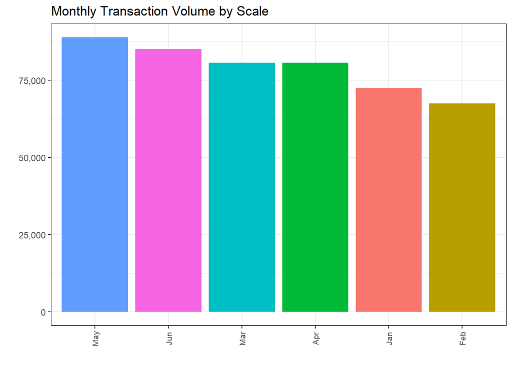

```r
tablo_son %>%
  filter(transaction_credit_card > 0 & transaction_debit_card_ > 0) %>%
  select(transaction_credit_card,transaction_debit_card_,amount_of_purchase_credit_card,amount_of_purchase_debit_card,month) %>%
  arrange(desc(month),desc(amount_of_purchase_credit_card)) %>%
  group_by(month) %>%
  summarize(month_total = sum(amount_of_purchase_debit_card, amount_of_purchase_credit_card)) %>%
  arrange(desc(month_total))%>%
  ggplot(data = ., aes(x = workplace, y = month_total,
                       fill = as.character(month))) + geom_bar(stat = "identity") + aes(x = reorder(month, -month_total),
                                                                                       y =month_total) + labs(x = "", y = "", title = "Monthly Transaction Volume by Scale") + theme_bw() + theme( axis.text.x = element_text(angle = 90,
                                                                                                                                                                                                               vjust = 0.49, hjust = 0.49, size = 8)) + scale_y_continuous(labels = scales::comma) + scale_x_discrete(labels = c("May", "Jun","Mar", "Apr", "Jan", "Feb")) + theme(legend.position = "none")
```

Understanding grocery and shopping malls are the biggest source of both credit card and debit card transactions in Turkey in half one of year 2019.

```r
tablo_son %>%
  select(workplace, transaction_credit_card,transaction_debit_card_,amount_of_purchase_credit_card,amount_of_purchase_debit_card,month) %>%
  group_by(workplace) %>%
  summarize(sales=sum(transaction_credit_card, transaction_debit_card_)) %>%
  mutate(share = round(sales/sum(sales),2)) %>%
  arrange(desc(share)) %>%
  print(share)
```

```
## # A tibble: 26 x 3
##    workplace                                 sales share
##    <chr>                                     <dbl> <dbl>
##  1 MARKET VE ALISVERIS MERKEZLERI        957742221  0.31
##  2 YEMEK                                 486166406  0.16
##  3 ÇESITLI GIDA                          286302262  0.09
##  4 BENZIN VE YAKIT ISTASYONLARI          228279355  0.07
##  5 GIYIM VE AKSESUAR                     226946321  0.07
##  6 HIZMET SEKTÖRLERI                     174318580  0.06
##  7 SAGLIK/SAGLIK ÜRÜNLERI/KOZMETIK       132787104  0.04
##  8 TELEKOMÜNIKASYON                      127338414  0.04
##  9 DIGER                                  88334580  0.03
## 10 EGITIM / KIRTASIYE / OFIS MALZEMELERI  50742892  0.02
## # ... with 16 more rows
```